# Project 7 : Titanic Survival Prediction: A Comparative Analysis of Classification Models

Phubordin Phanyosri

2025-07

# 1 คำแนะนำ :

ถ้าคุณดูผ่าน Github แนะนำให้กด Ctrl+F เพื่อไปยังหัวข้อที่สนใจ (ที่บอกมาจาก [My Portfolio Website](https://phubordin.github.io/My-Portfolio-Website/project_titanic_glm_dsb10.html))

# 2 Load Library/Data

สำหรับข้อมูล titanic ผมจะนำข้อมูลชุด train และ test มารวมกัน และค่อยสุ่มแยกเป็น 2 ชุดภายหลังจาก การ Cleansing ข้อมูลแล้ว จากนั้นเริ่มเทรนโมเดล และประเมินผลโมเดล (Evaluate) ภายหลัง

## 2.1 Load Library

```r
library(readxl)
library(knitr)
library(caret)
library(tidyverse)
```

```r
library(rpart.plot)
library(titanic)
library(scales)
library(corrplot)
```

## 2.2 Load Titanic Data

```r
data("titanic_train")
data("titanic_test")

titanic_train$Source <- "titanic_train"
titanic_test$Source <- "titanic_test"

titanic_data <- bind_rows(titanic_train, titanic_test)
```

# 3 Explore Data

## 3.1 Summary Basic Stats

```r
# สรุปสถิติเบื้องต้น
titanic_data |> summary()
```

```
##   PassengerId      Survived          Pclass          Name
##  Min.   :   1   Min.   :0.0000   Min.   :1.000   Length:1309
##  1st Qu.: 328   1st Qu.:0.0000   1st Qu.:2.000   Class :character
##  Median : 655   Median :0.0000   Median :3.000   Mode  :character
##  Mean   : 655   Mean   :0.3838   Mean   :2.295
##  3rd Qu.: 982   3rd Qu.:1.0000   3rd Qu.:3.000
##  Max.   :1309   Max.   :1.0000   Max.   :3.000
##                 NA's   :418
##      Sex                 Age            SibSp            Parch
##  Length:1309        Min.   : 0.17   Min.   :0.0000   Min.   :0.000
##  Class :character   1st Qu.:21.00   1st Qu.:0.0000   1st Qu.:0.000
##  Mode  :character   Median :28.00   Median :0.0000   Median :0.000
##                     Mean   :29.88   Mean   :0.4989   Mean   :0.385
##                     3rd Qu.:39.00   3rd Qu.:1.0000   3rd Qu.:0.000
##                     Max.   :80.00   Max.   :8.0000   Max.   :9.000
##                     NA's   :263
##     Ticket               Fare            Cabin             Embarked
##  Length:1309        Min.   :  0.000   Length:1309        Length:1309
##  Class :character   1st Qu.:  7.896   Class :character   Class :character
##  Mode  :character   Median : 14.454   Mode  :character   Mode  :character
##                     Mean   : 33.295
##                     3rd Qu.: 31.275
##                     Max.   :512.329
##                     NA's   :1
##     Source
##  Length:1309
##  Class :character
##  Mode  :character
##
##
##
##
```

## 3.2 Data Glimpse

```r
# โครงสร้างตาราง diamonds กี่แถว กี่คอลัมน์ ประเภทคอลัมน์
titanic_data |> glimpse()
```

```
## Rows: 1,309
## Columns: 13
## $ PassengerId <int> 1, 2, 3, 4, 5, 6, 7, 8, 9, 10, 11, 12, 13, 14, 15, 16, 17,…
## $ Survived    <int> 0, 1, 1, 1, 0, 0, 0, 0, 1, 1, 1, 1, 0, 0, 0, 1, 0, 1, 0, 1…
## $ Pclass      <int> 3, 1, 3, 1, 3, 3, 1, 3, 3, 2, 3, 1, 3, 3, 3, 2, 3, 2, 3, 3…
## $ Name        <chr> "Braund, Mr. Owen Harris", "Cumings, Mrs. John Bradley (Fl…
## $ Sex         <chr> "male", "female", "female", "female", "male", "male", "mal…
## $ Age         <dbl> 22, 38, 26, 35, 35, NA, 54, 2, 27, 14, 4, 58, 20, 39, 14, …
## $ SibSp       <int> 1, 1, 0, 1, 0, 0, 0, 3, 0, 1, 1, 0, 0, 1, 0, 0, 4, 0, 1, 0…
## $ Parch       <int> 0, 0, 0, 0, 0, 0, 0, 1, 2, 0, 1, 0, 0, 5, 0, 0, 1, 0, 0, 0…
## $ Ticket      <chr> "A/5 21171", "PC 17599", "STON/O2. 3101282", "113803", "37…
## $ Fare        <dbl> 7.2500, 71.2833, 7.9250, 53.1000, 8.0500, 8.4583, 51.8625,…
## $ Cabin       <chr> "", "C85", "", "C123", "", "", "E46", "", "", "", "G6", "C…
## $ Embarked    <chr> "S", "C", "S", "S", "S", "Q", "S", "S", "S", "C", "S", "S"…
## $ Source      <chr> "titanic_train", "titanic_train", "titanic_train", "titani…
```

## 3.3 Preview Data

ตาราง `titanic_data` เป็นข้อมูลเกี่ยวกับเหตุการณ์เรือไททานิคอับปาง เนื่องจากการชนภูเขาน้ำแข็งในวันที่ 14 เมษายน ค.ศ.1912 โดยมีคอลัมน์ต่อไปนี้

| Cols | Description | Type |
| --- | --- | --- |
| `PassengerId` | หมายเลข ID ผู้โดยสาร (ลำดับ row) | Integer |
| `Survived` | สถานะการรอดชีวิต (0 = ไม่รอด, 1 = รอด) | Integer (ควรแปลงเป็น `factor`) |
| `Pclass` | ชั้นโดยสาร (1 = บนสุด, 3 = ล่างสุด) | Integer (`ordered`) |
| `Name` | ชื่อเต็มของผู้โดยสาร | Character |
| `Sex` | เพศของผู้โดยสาร (`male`, `female`) | Character (ควรแปลงเป็น `factor`) |
| `Age` | อายุ (อาจมี `NA`) | Numeric |
| `SibSp` | จำนวนพี่น้องหรือคู่สมรสร่วมเดินทาง | Integer |
| `Parch` | จำนวนพ่อแม่หรือลูกที่เดินทางร่วมกัน | Integer |
| `Ticket` | หมายเลขตั๋ว (อาจมีรหัสซ้ำหรือคล้ายกัน) | Character |
| `Fare` | ราคาตั๋วที่จ่าย | Numeric |
| `Cabin` | หมายเลขห้องพัก (มี missing เยอะมาก) | Character (ส่วนใหญ่ `NA`) |
| `Embarked` | ท่าเรือที่ขึ้นเรือ (`C`, `Q`, `S`) | Character (ควรแปลงเป็น `factor`) |

### 3.3.1 First 6 Rows

**ดู 6 แถวแรก(ไม่รวมหัวตาราง) kable ปรับตารางให้ดูเหมาะสม**

```r
titanic_data |>
  head()
```

|  | PassengerId | Survived | Pclass | Name | Sex | Age | SibSp | Parch | Ticket | Fare | Cabin | Embarked | Source |
| --- | --- | --- | --- | --- | --- | --- | --- | --- | --- | --- | --- | --- | --- |
| 1 | 1 | 0 | 3 | Braund, Mr. Owen Harris | male | 22 | 1 | 0 | A/5 21171 | 7.2500 |  | S | titanic_train |
| 2 | 2 | 1 | 1 | Cumings, Mrs. John Bradley (Florence Briggs Thayer) | female | 38 | 1 | 0 | PC 17599 | 71.2833 | C85 | C | titanic_train |
| 3 | 3 | 1 | 3 | Heikkinen, Miss. Laina | female | 26 | 0 | 0 | STON/O2. 3101282 | 7.9250 |  | S | titanic_train |
| 4 | 4 | 1 | 1 | Futrelle, Mrs. Jacques Heath (Lily May Peel) | female | 35 | 1 | 0 | 113803 | 53.1000 | C123 | S | titanic_train |
| 5 | 5 | 0 | 3 | Allen, Mr. William Henry | male | 35 | 0 | 0 | 373450 | 8.0500 |  | S | titanic_train |
| 6 | 6 | 0 | 3 | Moran, Mr. James | male | NA | 0 | 0 | 330877 | 8.4583 |  | Q | titanic_train |

### 3.3.2 Last 6 Rows

**ดู 6 แถวท้าย(ไม่รวมหัวตาราง) kable ปรับตารางให้ดูเหมาะสม**

```r
titanic_data |>
  tail()
```

|  | PassengerId | Survived | Pclass | Name | Sex | Age | SibSp | Parch | Ticket | Fare | Cabin | Embarked | Source |
| --- | --- | --- | --- | --- | --- | --- | --- | --- | --- | --- | --- | --- | --- |
| 1304 | 1304 | NA | 3 | Henriksson, Miss. Jenny Lovisa | female | 28.0 | 0 | 0 | 347086 | 7.7750 |  | S | titanic_test |
| 1305 | 1305 | NA | 3 | Spector, Mr. Woolf | male | NA | 0 | 0 | A.5. 3236 | 8.0500 |  | S | titanic_test |
| 1306 | 1306 | NA | 1 | Oliva y Ocana, Dona. Fermina | female | 39.0 | 0 | 0 | PC 17758 | 108.9000 | C105 | C | titanic_test |
| 1307 | 1307 | NA | 3 | Saether, Mr. Simon Sivertsen | male | 38.5 | 0 | 0 | SOTON/O.Q. 3101262 | 7.2500 |  | S | titanic_test |
| 1308 | 1308 | NA | 3 | Ware, Mr. Frederick | male | NA | 0 | 0 | 359309 | 8.0500 |  | S | titanic_test |
| 1309 | 1309 | NA | 3 | Peter, Master. Michael J | male | NA | 1 | 1 | 2668 | 22.3583 |  | C | titanic_test |

## 3.4 Duplicate Rows

```r
# ตรวจสอบว่ามีแถวซ้ำกันไหม TRUE มี, False ไม่มี
titanic_data |> distinct() |> count() !=  titanic_data |> count()
```

```
##          n
## [1,] FALSE
```

## 3.5 Explore NA and Missing Value

### 3.5.1 Rows with at least one NA in any column

```r
# เลือกแถวที่มีค่า NA อย่างน้อย 1 คอลัมน์
titanic_data |> filter(if_any(everything(), is.na)) |> glimpse()
```

```
## Rows: 595
## Columns: 13
## $ PassengerId <int> 6, 18, 20, 27, 29, 30, 32, 33, 37, 43, 46, 47, 48, 49, 56,…
## $ Survived    <int> 0, 1, 1, 0, 1, 0, 1, 1, 1, 0, 0, 0, 1, 0, 1, 0, 1, 0, 0, 1…
## $ Pclass      <int> 3, 2, 3, 3, 3, 3, 1, 3, 3, 3, 3, 3, 3, 3, 1, 1, 3, 3, 3, 3…
## $ Name        <chr> "Moran, Mr. James", "Williams, Mr. Charles Eugene", "Masse…
## $ Sex         <chr> "male", "male", "female", "male", "female", "male", "femal…
## $ Age         <dbl> NA, NA, NA, NA, NA, NA, NA, NA, NA, NA, NA, NA, NA, NA, NA…
## $ SibSp       <int> 0, 0, 0, 0, 0, 0, 1, 0, 0, 0, 0, 1, 0, 2, 0, 0, 1, 0, 0, 0…
## $ Parch       <int> 0, 0, 0, 0, 0, 0, 0, 0, 0, 0, 0, 0, 0, 0, 0, 0, 1, 0, 0, 0…
## $ Ticket      <chr> "330877", "244373", "2649", "2631", "330959", "349216", "P…
## $ Fare        <dbl> 8.4583, 13.0000, 7.2250, 7.2250, 7.8792, 7.8958, 146.5208,…
## $ Cabin       <chr> "", "", "", "", "", "", "B78", "", "", "", "", "", "", "",…
## $ Embarked    <chr> "Q", "S", "C", "C", "Q", "S", "C", "Q", "C", "C", "S", "Q"…
## $ Source      <chr> "titanic_train", "titanic_train", "titanic_train", "titani…
```

### 3.5.2 Rows with NA or Empty Values in Any Column

```r
# เลือกแถวที่มี NA หรือค่าว่างมา อย่างน้อย 1 คอลัมน์
titanic_data |> filter(if_any(everything(), ~ is.na(.) | . == "")) |> glimpse()
```

```
## Rows: 1,126
## Columns: 13
## $ PassengerId <int> 1, 3, 5, 6, 8, 9, 10, 13, 14, 15, 16, 17, 18, 19, 20, 21, …
## $ Survived    <int> 0, 1, 0, 0, 0, 1, 1, 0, 0, 0, 1, 0, 1, 0, 1, 0, 1, 0, 1, 0…
## $ Pclass      <int> 3, 3, 3, 3, 3, 3, 2, 3, 3, 3, 2, 3, 2, 3, 3, 2, 3, 3, 3, 3…
## $ Name        <chr> "Braund, Mr. Owen Harris", "Heikkinen, Miss. Laina", "Alle…
## $ Sex         <chr> "male", "female", "male", "male", "male", "female", "femal…
## $ Age         <dbl> 22, 26, 35, NA, 2, 27, 14, 20, 39, 14, 55, 2, NA, 31, NA, …
## $ SibSp       <int> 1, 0, 0, 0, 3, 0, 1, 0, 1, 0, 0, 4, 0, 1, 0, 0, 0, 3, 1, 0…
## $ Parch       <int> 0, 0, 0, 0, 1, 2, 0, 0, 5, 0, 0, 1, 0, 0, 0, 0, 0, 1, 5, 0…
## $ Ticket      <chr> "A/5 21171", "STON/O2. 3101282", "373450", "330877", "3499…
## $ Fare        <dbl> 7.2500, 7.9250, 8.0500, 8.4583, 21.0750, 11.1333, 30.0708,…
## $ Cabin       <chr> "", "", "", "", "", "", "", "", "", "", "", "", "", "", ""…
## $ Embarked    <chr> "S", "S", "S", "Q", "S", "S", "C", "S", "S", "S", "S", "Q"…
## $ Source      <chr> "titanic_train", "titanic_train", "titanic_train", "titani…
```

### 3.5.3 Columns with at least one NA in any row

```r
# เลือกคอลัมน์ที่มี NA อย่างน้อย 1 แถว
titanic_data |> select(where(~ any(is.na(.)))) |> glimpse()
```

```
## Rows: 1,309
## Columns: 3
## $ Survived <int> 0, 1, 1, 1, 0, 0, 0, 0, 1, 1, 1, 1, 0, 0, 0, 1, 0, 1, 0, 1, 0…
## $ Age      <dbl> 22, 38, 26, 35, 35, NA, 54, 2, 27, 14, 4, 58, 20, 39, 14, 55,…
## $ Fare     <dbl> 7.2500, 71.2833, 7.9250, 53.1000, 8.0500, 8.4583, 51.8625, 21…
```

### 3.5.4 Columns Containing NA or Empty Values in Any Row

```r
# เลือกคอลัมน์ที่มี NA หรือค่าว่าง มาอย่างน้อย 1 แถว
titanic_data |> select(where(~ any(is.na(.) | . == ""))) |> glimpse()
```

```
## Rows: 1,309
## Columns: 5
## $ Survived <int> 0, 1, 1, 1, 0, 0, 0, 0, 1, 1, 1, 1, 0, 0, 0, 1, 0, 1, 0, 1, 0…
## $ Age      <dbl> 22, 38, 26, 35, 35, NA, 54, 2, 27, 14, 4, 58, 20, 39, 14, 55,…
## $ Fare     <dbl> 7.2500, 71.2833, 7.9250, 53.1000, 8.0500, 8.4583, 51.8625, 21…
## $ Cabin    <chr> "", "C85", "", "C123", "", "", "E46", "", "", "", "G6", "C103…
## $ Embarked <chr> "S", "C", "S", "S", "S", "Q", "S", "S", "S", "C", "S", "S", "…
```

## 3.6 Explore 5 Columns NA / Missing Value

เราจะมาสำรวจดูกันว่า 5 คอลัมน์ที่พบ NA หรือค่าว่างอย่างน้อย 1 แถวนั้นเป็นค่า NA หรือ ค่าว่าง หรือเป็นทั้ง 2 ในคอลัมน์เดียวกันเลย โดยเราจะเริ่มที่

1. Survived
2. Age
3. Fare
4. Cabin
5. Embarked

### 3.6.1 NA Survived

**ตรวจสอบว่าคอลัมน์ Survived มีค่า NA ไหม**

```r
titanic_data |>
  select(Survived) |>
  filter(Survived %in% c(NA)) |>
  glimpse()
```

```
## Rows: 418
## Columns: 1
## $ Survived <int> NA, NA, NA, NA, NA, NA, NA, NA, NA, NA, NA, NA, NA, NA, NA, N…
```

### 3.6.2 NA Age

**ตรวจสอบว่าคอลัมน์ Age มีค่า NA ไหม**

```r
titanic_data |>
  select(Age) |>
  filter(Age %in% c(NA)) |>
  glimpse()
```

```
## Rows: 263
## Columns: 1
## $ Age <dbl> NA, NA, NA, NA, NA, NA, NA, NA, NA, NA, NA, NA, NA, NA, NA, NA, NA…
```

### 3.6.3 NA Fare

**ตรวจสอบว่าคอลัมน์ Fare มีค่า NA ไหม**

```r
titanic_data |>
  select(Fare) |>
  filter(Fare %in% c(NA)) |>
  glimpse()
```

```
## Rows: 1
## Columns: 1
## $ Fare <dbl> NA
```

### 3.6.4 NA Cabin

**ตรวจสอบว่าคอลัมน์ Cabin มีค่า NA ไหม**

```r
titanic_data |>
  select(Cabin) |>
  filter(Cabin %in% c(NA)) |>
  glimpse()
```

```
## Rows: 0
## Columns: 1
## $ Cabin <chr>
```

### 3.6.5 NA Embarked

**ตรวจสอบว่าคอลัมน์ Embarked มีค่า NA ไหม**

```r
titanic_data |>
  select(Embarked) |>
  filter(Embarked %in% c(NA)) |>
  glimpse()
```

```
## Rows: 0
## Columns: 1
## $ Embarked <chr>
```

### 3.6.6 Missing Value Survived

**ตรวจสอบว่าคอลัมน์ Survived มีค่า ว่าง ไหม**

```r
titanic_data |>
  select(Survived) |>
  filter(Survived %in% c("")) |>
  glimpse()
```

```
## Rows: 0
## Columns: 1
## $ Survived <int>
```

### 3.6.7 Missing Value Age

**ตรวจสอบว่าคอลัมน์ Age มีค่า ว่าง ไหม**

```r
titanic_data |>
  select(Age) |>
  filter(Age %in% c("")) |>
  glimpse()
```

```
## Rows: 0
## Columns: 1
## $ Age <dbl>
```

### 3.6.8 Missing Value Cabin

**ตรวจสอบว่าคอลัมน์ Cabin มีค่า ว่าง ไหม**

```r
titanic_data |>
  select(Cabin) |>
  filter(Cabin %in% c("")) |>
  glimpse()
```

```
## Rows: 1,014
## Columns: 1
## $ Cabin <chr> "", "", "", "", "", "", "", "", "", "", "", "", "", "", "", "", …
```

### 3.6.9 Missing Value Embarked

**ตรวจสอบว่าคอลัมน์ Embarked มีค่า ว่าง ไหม**

```r
titanic_data |>
  select(Embarked) |>
  filter(Embarked %in% c("")) |>
  glimpse()
```

```
## Rows: 2
## Columns: 1
## $ Embarked <chr> "", ""
```

### 3.6.10 Check NA Survived

พบว่า คอลัมน์ Survived มีแต่ค่า NA ไม่พบค่าว่าง เนื่องจากตอนเรา `bind_rows(titanic_train, titanic_test)` พบว่า `titanic_test` ไม่มีคอลัมน์ `Survived` ทำให้เกิดค่า NA ในคอลัมน์ `Survived` ที่มาจาก `titanic_test` ตรวจสอบดูว่า มาจาก `titanic_test` และมีกี่แถว

```r
titanic_data |>
  filter(Survived %in% c(NA)) |>
  group_by(Source) |>
  summarise(N_A = n()) |>
  kable()
```

| Source | N_A |
| --- | --- |
| titanic_test | 418 |

### 3.6.11 Check NA Age

**เช็ค NA ว่ามีกี่ค่ามาจากข้อมูลชุดไหน `Train` หรือ `Test`**

```r
titanic_data |>
  filter(Age %in% c(NA)) |>
  group_by(Source) |>
  summarise(N_A = n()) |>
  kable()
```

| Source | N_A |
| --- | --- |
| titanic_test | 86 |
| titanic_train | 177 |

### 3.6.12 Check NA Fare

**เช็ค NA ว่ามีกี่ค่ามาจากข้อมูลชุดไหน `Train` หรือ `Test`**

```r
titanic_data |>
  filter(Fare %in% c(NA)) |>
  group_by(Source) |>
  summarise(N_A = n()) |>
  kable()
```

| Source | N_A |
| --- | --- |
| titanic_test | 1 |

### 3.6.13 Check Missing Value Cabin

**เช็ค Missing Value ว่ามีกี่ค่ามาจากข้อมูลชุดไหน `Train` หรือ `Test`**

```r
titanic_data |>
  filter(Cabin %in% c("")) |>
  group_by(Source) |>
  summarise(Missing_Value = n()) |>
  kable()
```

| Source | Missing_Value |
| --- | --- |
| titanic_test | 327 |
| titanic_train | 687 |

### 3.6.14 Check Missing Value Embarked

**เช็ค Missing Value ว่ามีกี่ค่ามาจากข้อมูลชุดไหน `Train` หรือ `Test`**

```r
titanic_data |>
  filter(Embarked %in% c("")) |>
  group_by(Source) |>
  summarise(Missing_Value = n()) |>
  kable()
```

| Source | Missing_Value |
| --- | --- |
| titanic_train | 2 |

# 4 Clensing Titanic Dataset

จากหัวข้อที่ผ่านมาสรุปได้ดังนี้

| Columns | NA | Missing Value |
| --- | --- | --- |
| Survived | train 0, test 418 | train 0, test 0 |
| Age | train 177, test 86 | train 0, test 0 |
| Fare | train 0, test 1 | train 0, test 0 |
| Cabin | train 0, test 0 | train 687, test 327 |
| Embarked | train 0, test 0 | train 2, test 0 |

ดังนั้นเราจะมาจัดการค่า NA กับ Missing Value ตามลำดับ กันเลยครับ โดยผมจะจัดการแต่ละคอลัมน์ ดังนี้

1. `Survived` : NA เกิดจาก `titanic_test` ไม่มีคอลัมน์ `Survived` ตอน `bind_rows` จึงเกิด NA วิธีการจัดการ NA ผมใช้ AI สร้างคอลัมน์ 3 คอลัมน์ Name, Survived, Reference แล้วสุ่มตรวจคนรอดกับคนไม่รอดอย่างละ 5 คน พบว่าส่วนใหญ่ ไม่ ตรงกับลิงก์ที่ให้มา ผมจำเป็น ที่ต้องตรวจสอบผู้โดยสารทีละคนเลยว่า รอดชีวิตตาม Public Website หรือไม่ แล้วนำไป บันทึกลงไฟล์ `.xlsx`
2. `Age` : มี NA ทั้งใน test, train วิธีการจัดการกับ NA ผมก็ทำเหมือนข้อแรกที่ผ่านมาใช้ AI และสุ่มตรวจสอบ พบว่า ไม่ตรงกัน เราจึงตรวจสอบและบันทึกผลผู้โดยสารทีละคนลงไฟล์ `.xlsx` เช่นเดียวกัน แต่ ! จะมีผู้โดยสารอยู่ 2 คนที่ไม่มีการบันทึกที่แน่ชัดเลยว่าอายุ เท่าไร คือ

   ```
     2.1 ) 43 Kraeff, Mr. Theodor ไม่พบอายุที่แน่ชัด
     2.2 ) 421 Gheorgheff, Mr. Stanio ไม่พบอายุที่แน่ชัด
   ```

3. `Fare` : เกิด NA ราคาตั๋วโดยสารของผู้โดยสาร `1044 Storey, Mr. Thomas` 1 ค่า ในปี 1912 (ช่วงเรือไททานิค) สหราชอาณาจักรใช้ระบบเงินตราดังนี้:

   ```
      1 ปอนด์ (£1) = 20 ชิลลิง (s)
      1 ชิลลิง (s) = 12 เพนนี (d)

      คุณ `Thomas` มี 7 ปอนด์ 5 ชิลลิง แสดงว่าเราจะต้องแทนค่า NA นี้เท่ากับ `7.25` ปอนด์
      บันทึกลงไฟล์ `.xlsx`
   ```

4. `Cabin` : ข้อมูลของผู้โดยสารทั้งหมดมี 1309 คน พบว่ามีค่า Missing Value `Cabin` อยู่ 1014 คน คิดเป็น `~77%` และ `Cabin` คือหมายเลขห้องผู้โดยสาร ที่มันอาจไม่ส่งผลหรือส่งผลน้อยมาก อย่างมีนัยยะสำคัญกับการรอดชีวิตของผู้โดยสาร ดังนั้น วิธีจัดการ กับ Missing Value นี้ ผมจะตัดคอลัมน์นี้ทิ้ง ก่อนเทรนโมเดลนะครับ
5. `Embarked` : ท่าเรือที่ออกเดินทาง พบ Missing Value 2 ค่า คือ ของคุณ

   ```
     5.1 ) 62   Icard, Miss. Amelie หาจากลิงก์ข้อ 1. พบว่าขึ้นที่ท่า Southampton (S)
     5.2 ) 830 Stone, Mrs. George Nelson (Martha Evelyn) Southampton (S)

     บันทึกลงไฟล์ `.xlsx`
   ```

ดังนั้นข้อ 4 ผมจะตัดคอลัมน์ทิ้ง ส่วนข้อ 1-3, 5 ผมจะใช้ไฟล์ที่เก็บข้อมูลมาแทนค่า NA แต่อย่างที่บอกไปว่า ผู้โดยสารที่ไม่มี Age มีอยู่ 2 คน ดังนั้นผมจะแทนด้วยค่ากลางของข้อมูลหลังจากแทนที่ค่า NA ส่วนอื่นๆไปหมดแล้ว ต้องไปดูอีกทีว่าข้อมูลกระจายตัวยังไง แทนด้วย mean, median, mode แบบไหนดีกว่ากัน ปล. ผมจะไม่ตัดแถวที่มี NA ทิ้ง เพราะบางคอลัมน์เหมาะสมที่จะนำไปเทรนโมเดล + การจัดการ NA ที่ดีที่สุด คือไปแก้ที่ข้อมูลต้นทาง

ก่อนอื่นผมจะ นำ 2 ไฟล์ที่ผมไปหาข้อมูลมาแล้ว import เข้า Rstudio ก่อน และค่อยทำการแทนที่ค่า NA และ Missing Value ภายหลัง

## 4.1 Read / Preview Fill_NA_Test.xlsx File

```r
fill_na_test <- read_excel("Fill_NA_Test.xlsx")

fill_na_test <- fill_na_test |> select(PassengerId, Name_Test, Survived_Test, Age_Test, Fare_Test)

fill_na_test |> head(30) |> kable(
  col.names = c("PassengerId", "Name", "Survived", "Age", "Fare")
  )
```

| PassengerId | Name | Survived | Age | Fare |
| --- | --- | --- | --- | --- |
| 892 | Kelly, Mr. James | 0 | 34.5 | 7.8292 |
| 893 | Wilkes, Mrs. James (Ellen Needs) | 1 | 47.0 | 7.0000 |
| 894 | Myles, Mr. Thomas Francis | 0 | 62.0 | 9.6875 |
| 895 | Wirz, Mr. Albert | 0 | 27.0 | 8.6625 |
| 896 | Hirvonen, Mrs. Alexander (Helga E Lindqvist) | 1 | 22.0 | 12.2875 |
| 897 | Svensson, Mr. Johan Cervin | 1 | 14.0 | 9.2250 |
| 898 | Connolly, Miss. Kate | 1 | 30.0 | 7.6292 |
| 899 | Caldwell, Mr. Albert Francis | 1 | 26.0 | 29.0000 |
| 900 | Abrahim, Mrs. Joseph (Sophie Halaut Easu) | 1 | 18.0 | 7.2292 |
| 901 | Davies, Mr. John Samuel | 0 | 21.0 | 24.1500 |
| 902 | Ilieff, Mr. Ylio | 0 | 32.0 | 7.8958 |
| 903 | Jones, Mr. Charles Cresson | 0 | 46.0 | 26.0000 |
| 904 | Snyder, Mrs. John Pillsbury (Nelle Stevenson) | 1 | 23.0 | 82.2667 |
| 905 | Howard, Mr. Benjamin | 0 | 63.0 | 26.0000 |
| 906 | Chaffee, Mrs. Herbert Fuller (Carrie Constance Toogood) | 1 | 47.0 | 61.1750 |
| 907 | del Carlo, Mrs. Sebastiano (Argenia Genovesi) | 1 | 24.0 | 27.7208 |
| 908 | Keane, Mr. Daniel | 0 | 35.0 | 12.3500 |
| 909 | Assaf, Mr. Gerios | 0 | 21.0 | 7.2250 |
| 910 | Ilmakangas, Miss. Ida Livija | 0 | 27.0 | 7.9250 |
| 911 | Assaf Khalil, Mrs. Mariana (Miriam”)” | 1 | 45.0 | 7.2250 |
| 912 | Rothschild, Mr. Martin | 0 | 55.0 | 59.4000 |
| 913 | Olsen, Master. Artur Karl | 1 | 9.0 | 3.1708 |
| 914 | Flegenheim, Mrs. Alfred (Antoinette) | 1 | 48.0 | 31.6833 |
| 915 | Williams, Mr. Richard Norris II | 1 | 21.0 | 61.3792 |
| 916 | Ryerson, Mrs. Arthur Larned (Emily Maria Borie) | 1 | 48.0 | 262.3750 |
| 917 | Robins, Mr. Alexander A | 0 | 50.0 | 14.5000 |
| 918 | Ostby, Miss. Helene Ragnhild | 1 | 22.0 | 61.9792 |
| 919 | Daher, Mr. Shedid | 0 | 22.5 | 7.2250 |
| 920 | Brady, Mr. John Bertram | 0 | 41.0 | 30.5000 |
| 921 | Samaan, Mr. Elias | 0 | 17.0 | 21.6792 |

## 4.2 Read / Preview Fill_NA_Train.xlsx File

```r
fill_na_train <- read_excel("Fill_NA_Train.xlsx")

fill_na_train <- fill_na_train |> select(PassengerId, Name_Train, Survived_Train, Age_Train, Embarked_Train)

fill_na_train |> head(30) |> kable(
  col.names = c("PassengerId", "Name", "Survived", "Age", "Embarked")
  )
```

| PassengerId | Name | Survived | Age | Embarked |
| --- | --- | --- | --- | --- |
| 6 | Moran, Mr. James | 0 | 28 | Q |
| 18 | Williams, Mr. Charles Eugene | 1 | 23 | S |
| 20 | Masselmani, Mrs. Fatima | 1 | 22 | C |
| 27 | Emir, Mr. Farred Chehab | 0 | 26 | C |
| 29 | O’Dwyer, Miss. Ellen “Nellie” | 1 | 22 | Q |
| 30 | Todoroff, Mr. Lalio | 0 | 23 | S |
| 32 | Spencer, Mrs. William Augustus (Marie Eugenie) | 1 | 48 | C |
| 33 | Glynn, Miss. Mary Agatha | 1 | 18 | Q |
| 37 | Mamee, Mr. Hanna | 1 | 20 | C |
| 43 | Kraeff, Mr. Theodor | 0 | NA | C |
| 46 | Rogers, Mr. William John | 0 | 30 | S |
| 47 | Lennon, Mr. Denis | 0 | 20 | Q |
| 48 | O’Driscoll, Miss. Bridget | 1 | 27 | Q |
| 49 | Samaan, Mr. Youssef | 0 | 16 | C |
| 56 | Woolner, Mr. Hugh | 1 | 45 | S |
| 62 | Icard, Miss. Amelie | 1 | 38 | S |
| 65 | Stewart, Mr. Albert A | 0 | 64 | C |
| 66 | Moubarek, Master. Gerios | 1 | 7 | C |
| 77 | Staneff, Mr. Ivan | 0 | 23 | S |
| 78 | Moutal, Mr. Rahamin Haim | 0 | 28 | S |
| 83 | McDermott, Miss. Brigdet Delia | 1 | 31 | Q |
| 88 | Slocovski, Mr. Selman Francis | 0 | 20 | S |
| 96 | Shorney, Mr. Charles Joseph | 0 | 22 | S |
| 102 | Petroff, Mr. Pastcho (“Pentcho”) | 0 | 29 | S |
| 108 | Moss, Mr. Albert Johan | 1 | 29 | S |
| 110 | Moran, Miss. Bertha | 1 | 28 | Q |
| 122 | Moore, Mr. Leonard Charles | 0 | 19 | S |
| 127 | McMahon, Mr. Martin | 0 | 19 | Q |
| 129 | Peter, Miss. Anna | 1 | 2 | C |
| 141 | Boulos, Mrs. Joseph (Sultana) | 0 | 40 | C |

## 4.3 Joining Tables for Data Preparation

```r
join_table <- titanic_data |>
  left_join(fill_na_test, by = "PassengerId") |>
  left_join(fill_na_train, by = "PassengerId")
join_table |> glimpse()
```

```
## Rows: 1,309
## Columns: 21
## $ PassengerId    <dbl> 1, 2, 3, 4, 5, 6, 7, 8, 9, 10, 11, 12, 13, 14, 15, 16, …
## $ Survived       <int> 0, 1, 1, 1, 0, 0, 0, 0, 1, 1, 1, 1, 0, 0, 0, 1, 0, 1, 0…
## $ Pclass         <int> 3, 1, 3, 1, 3, 3, 1, 3, 3, 2, 3, 1, 3, 3, 3, 2, 3, 2, 3…
## $ Name           <chr> "Braund, Mr. Owen Harris", "Cumings, Mrs. John Bradley …
## $ Sex            <chr> "male", "female", "female", "female", "male", "male", "…
## $ Age            <dbl> 22, 38, 26, 35, 35, NA, 54, 2, 27, 14, 4, 58, 20, 39, 1…
## $ SibSp          <int> 1, 1, 0, 1, 0, 0, 0, 3, 0, 1, 1, 0, 0, 1, 0, 0, 4, 0, 1…
## $ Parch          <int> 0, 0, 0, 0, 0, 0, 0, 1, 2, 0, 1, 0, 0, 5, 0, 0, 1, 0, 0…
## $ Ticket         <chr> "A/5 21171", "PC 17599", "STON/O2. 3101282", "113803", …
## $ Fare           <dbl> 7.2500, 71.2833, 7.9250, 53.1000, 8.0500, 8.4583, 51.86…
## $ Cabin          <chr> "", "C85", "", "C123", "", "", "E46", "", "", "", "G6",…
## $ Embarked       <chr> "S", "C", "S", "S", "S", "Q", "S", "S", "S", "C", "S", …
## $ Source         <chr> "titanic_train", "titanic_train", "titanic_train", "tit…
## $ Name_Test      <chr> NA, NA, NA, NA, NA, NA, NA, NA, NA, NA, NA, NA, NA, NA,…
## $ Survived_Test  <dbl> NA, NA, NA, NA, NA, NA, NA, NA, NA, NA, NA, NA, NA, NA,…
## $ Age_Test       <dbl> NA, NA, NA, NA, NA, NA, NA, NA, NA, NA, NA, NA, NA, NA,…
## $ Fare_Test      <dbl> NA, NA, NA, NA, NA, NA, NA, NA, NA, NA, NA, NA, NA, NA,…
## $ Name_Train     <chr> NA, NA, NA, NA, NA, "Moran, Mr. James", NA, NA, NA, NA,…
## $ Survived_Train <dbl> NA, NA, NA, NA, NA, 0, NA, NA, NA, NA, NA, NA, NA, NA, …
## $ Age_Train      <dbl> NA, NA, NA, NA, NA, 28, NA, NA, NA, NA, NA, NA, NA, NA,…
## $ Embarked_Train <chr> NA, NA, NA, NA, NA, "Q", NA, NA, NA, NA, NA, NA, NA, NA…
```

### 4.3.1 Survived Preparation

```r
prep_survived <- join_table |>
  mutate(
    Survived = coalesce(Survived, Survived_Test)
  )

prep_survived |> filter(Source == "titanic_test" & Survived) |> glimpse()
```

```
## Rows: 160
## Columns: 21
## $ PassengerId    <dbl> 893, 896, 897, 898, 899, 900, 904, 906, 907, 911, 913, …
## $ Survived       <dbl> 1, 1, 1, 1, 1, 1, 1, 1, 1, 1, 1, 1, 1, 1, 1, 1, 1, 1, 1…
## $ Pclass         <int> 3, 3, 3, 3, 2, 3, 1, 1, 2, 3, 3, 1, 1, 1, 1, 3, 1, 3, 3…
## $ Name           <chr> "Wilkes, Mrs. James (Ellen Needs)", "Hirvonen, Mrs. Ale…
## $ Sex            <chr> "female", "female", "male", "female", "male", "female",…
## $ Age            <dbl> 47, 22, 14, 30, 26, 18, 23, 47, 24, 45, 9, NA, 21, 48, …
## $ SibSp          <int> 1, 1, 0, 0, 1, 0, 1, 1, 1, 0, 0, 0, 0, 1, 0, 1, 1, 0, 0…
## $ Parch          <int> 0, 1, 0, 0, 1, 0, 0, 0, 0, 0, 1, 0, 1, 3, 1, 2, 0, 0, 0…
## $ Ticket         <chr> "363272", "3101298", "7538", "330972", "248738", "2657"…
## $ Fare           <dbl> 7.0000, 12.2875, 9.2250, 7.6292, 29.0000, 7.2292, 82.26…
## $ Cabin          <chr> "", "", "", "", "", "", "B45", "E31", "", "", "", "", "…
## $ Embarked       <chr> "S", "S", "S", "Q", "S", "C", "S", "S", "C", "C", "S", …
## $ Source         <chr> "titanic_test", "titanic_test", "titanic_test", "titani…
## $ Name_Test      <chr> "Wilkes, Mrs. James (Ellen Needs)", "Hirvonen, Mrs. Ale…
## $ Survived_Test  <dbl> 1, 1, 1, 1, 1, 1, 1, 1, 1, 1, 1, 1, 1, 1, 1, 1, 1, 1, 1…
## $ Age_Test       <dbl> 47, 22, 14, 30, 26, 18, 23, 47, 24, 45, 9, 48, 21, 48, …
## $ Fare_Test      <dbl> 7.0000, 12.2875, 9.2250, 7.6292, 29.0000, 7.2292, 82.26…
## $ Name_Train     <chr> NA, NA, NA, NA, NA, NA, NA, NA, NA, NA, NA, NA, NA, NA,…
## $ Survived_Train <dbl> NA, NA, NA, NA, NA, NA, NA, NA, NA, NA, NA, NA, NA, NA,…
## $ Age_Train      <dbl> NA, NA, NA, NA, NA, NA, NA, NA, NA, NA, NA, NA, NA, NA,…
## $ Embarked_Train <chr> NA, NA, NA, NA, NA, NA, NA, NA, NA, NA, NA, NA, NA, NA,…
```

### 4.3.2 Age Preparation

**แทนค่า NA ด้วย Age_Test เข้าไปในคอลัมน์ Age** มีค่า NA อยู่ใน train 177, test 86 ค่า

```r
prep_survived_age <- prep_survived |>
  mutate(
    Age = coalesce(Age, Age_Test),
    Age = coalesce(Age, Age_Train), # Age = coalesce(Age, Age_Test, Age_Train)
    Age = if_else(is.na(Age), median(Age, na.rm = TRUE), Age) # 28
  )

prep_survived_age |> glimpse()
```

```
## Rows: 1,309
## Columns: 21
## $ PassengerId    <dbl> 1, 2, 3, 4, 5, 6, 7, 8, 9, 10, 11, 12, 13, 14, 15, 16, …
## $ Survived       <dbl> 0, 1, 1, 1, 0, 0, 0, 0, 1, 1, 1, 1, 0, 0, 0, 1, 0, 1, 0…
## $ Pclass         <int> 3, 1, 3, 1, 3, 3, 1, 3, 3, 2, 3, 1, 3, 3, 3, 2, 3, 2, 3…
## $ Name           <chr> "Braund, Mr. Owen Harris", "Cumings, Mrs. John Bradley …
## $ Sex            <chr> "male", "female", "female", "female", "male", "male", "…
## $ Age            <dbl> 22, 38, 26, 35, 35, 28, 54, 2, 27, 14, 4, 58, 20, 39, 1…
## $ SibSp          <int> 1, 1, 0, 1, 0, 0, 0, 3, 0, 1, 1, 0, 0, 1, 0, 0, 4, 0, 1…
## $ Parch          <int> 0, 0, 0, 0, 0, 0, 0, 1, 2, 0, 1, 0, 0, 5, 0, 0, 1, 0, 0…
## $ Ticket         <chr> "A/5 21171", "PC 17599", "STON/O2. 3101282", "113803", …
## $ Fare           <dbl> 7.2500, 71.2833, 7.9250, 53.1000, 8.0500, 8.4583, 51.86…
## $ Cabin          <chr> "", "C85", "", "C123", "", "", "E46", "", "", "", "G6",…
## $ Embarked       <chr> "S", "C", "S", "S", "S", "Q", "S", "S", "S", "C", "S", …
## $ Source         <chr> "titanic_train", "titanic_train", "titanic_train", "tit…
## $ Name_Test      <chr> NA, NA, NA, NA, NA, NA, NA, NA, NA, NA, NA, NA, NA, NA,…
## $ Survived_Test  <dbl> NA, NA, NA, NA, NA, NA, NA, NA, NA, NA, NA, NA, NA, NA,…
## $ Age_Test       <dbl> NA, NA, NA, NA, NA, NA, NA, NA, NA, NA, NA, NA, NA, NA,…
## $ Fare_Test      <dbl> NA, NA, NA, NA, NA, NA, NA, NA, NA, NA, NA, NA, NA, NA,…
## $ Name_Train     <chr> NA, NA, NA, NA, NA, "Moran, Mr. James", NA, NA, NA, NA,…
## $ Survived_Train <dbl> NA, NA, NA, NA, NA, 0, NA, NA, NA, NA, NA, NA, NA, NA, …
## $ Age_Train      <dbl> NA, NA, NA, NA, NA, 28, NA, NA, NA, NA, NA, NA, NA, NA,…
## $ Embarked_Train <chr> NA, NA, NA, NA, NA, "Q", NA, NA, NA, NA, NA, NA, NA, NA…
```

**เหตุผลที่เราแทนค่า NA 2 ตัวสุดท้าย ด้้วย median = 28 เพราะว่า**

**ตั้งค่าธีมเริ่มต้น เพื่อนำไปใช้สำหรับทุกๆ Chart ในโปรเจกต์นี้** ยืมมาจาก [Project 6](https://phubordin.github.io/My-Portfolio-Website/project_vizdimond_dsb10.html) แวะไปได้ครับ

```r
custom_theme <- theme_linedraw() +
  theme(

    plot.title = element_text(
      face = "bold",
      size = rel(1.1),
      color = "black",
      margin = margin(b = 10)
    ),

    plot.subtitle = element_text(
      size = rel(0.9),
      color = "#2F4F4F",
      margin = margin(b = 15)
    ),

    plot.caption = element_text(
      size = 8,
      color = "#4A4A4A",
      margin = margin(t = 10)
    ),

    axis.title = element_text(
      size = 11,
      color = "#1C1C1C",
      face = "bold"
    ),

    panel.grid.major.y = element_blank(),
    panel.grid.major.x = element_blank(),
    panel.grid.minor.x = element_blank(),
    panel.grid.minor.y = element_blank(),
    legend.title = element_text(face = "bold"),
    legend.text = element_text(size = 10),
    panel.background = element_rect(fill = "white"),
    plot.margin = margin(15, 15, 15, 15)
  )
```

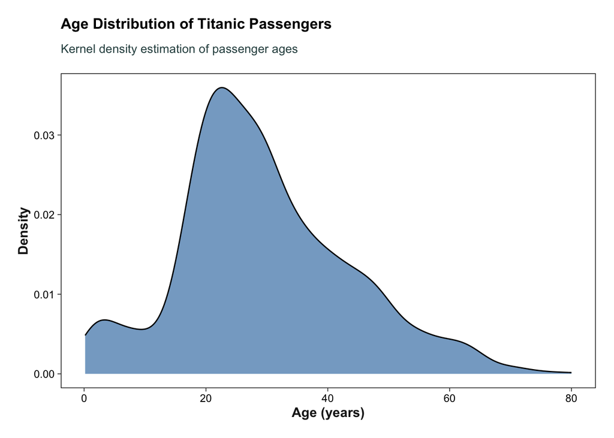

```r
prep_survived_age |>
  ggplot(aes(Age)) +
  geom_density(fill = "#4682B4", alpha = 0.7) +
  custom_theme +
  labs(
    title = "Age Distribution of Titanic Passengers",
    subtitle = "Kernel density estimation of passenger ages",
    x = "Age (years)",
    y = "Density"
  )
```

```r
prep_survived_age |>
  select(Age) |>
  summary()
```

```
##       Age
##  Min.   : 0.17
##  1st Qu.:21.00
##  Median :28.00
##  Mean   :29.64
##  3rd Qu.:38.00
##  Max.   :80.00
```

### 4.3.3 Fare Preparation

**แทนค่า NA ด้วย Fare_Test เข้าไปในคอลัมน์ Fare** มี 1 ค่าใน `titanic_test`

```r
prep_survived_age_fare <- prep_survived_age |>
  mutate(
    Fare = coalesce(Fare, Fare_Test)
  )

prep_survived_age_fare |> glimpse()
```

```
## Rows: 1,309
## Columns: 21
## $ PassengerId    <dbl> 1, 2, 3, 4, 5, 6, 7, 8, 9, 10, 11, 12, 13, 14, 15, 16, …
## $ Survived       <dbl> 0, 1, 1, 1, 0, 0, 0, 0, 1, 1, 1, 1, 0, 0, 0, 1, 0, 1, 0…
## $ Pclass         <int> 3, 1, 3, 1, 3, 3, 1, 3, 3, 2, 3, 1, 3, 3, 3, 2, 3, 2, 3…
## $ Name           <chr> "Braund, Mr. Owen Harris", "Cumings, Mrs. John Bradley …
## $ Sex            <chr> "male", "female", "female", "female", "male", "male", "…
## $ Age            <dbl> 22, 38, 26, 35, 35, 28, 54, 2, 27, 14, 4, 58, 20, 39, 1…
## $ SibSp          <int> 1, 1, 0, 1, 0, 0, 0, 3, 0, 1, 1, 0, 0, 1, 0, 0, 4, 0, 1…
## $ Parch          <int> 0, 0, 0, 0, 0, 0, 0, 1, 2, 0, 1, 0, 0, 5, 0, 0, 1, 0, 0…
## $ Ticket         <chr> "A/5 21171", "PC 17599", "STON/O2. 3101282", "113803", …
## $ Fare           <dbl> 7.2500, 71.2833, 7.9250, 53.1000, 8.0500, 8.4583, 51.86…
## $ Cabin          <chr> "", "C85", "", "C123", "", "", "E46", "", "", "", "G6",…
## $ Embarked       <chr> "S", "C", "S", "S", "S", "Q", "S", "S", "S", "C", "S", …
## $ Source         <chr> "titanic_train", "titanic_train", "titanic_train", "tit…
## $ Name_Test      <chr> NA, NA, NA, NA, NA, NA, NA, NA, NA, NA, NA, NA, NA, NA,…
## $ Survived_Test  <dbl> NA, NA, NA, NA, NA, NA, NA, NA, NA, NA, NA, NA, NA, NA,…
## $ Age_Test       <dbl> NA, NA, NA, NA, NA, NA, NA, NA, NA, NA, NA, NA, NA, NA,…
## $ Fare_Test      <dbl> NA, NA, NA, NA, NA, NA, NA, NA, NA, NA, NA, NA, NA, NA,…
## $ Name_Train     <chr> NA, NA, NA, NA, NA, "Moran, Mr. James", NA, NA, NA, NA,…
## $ Survived_Train <dbl> NA, NA, NA, NA, NA, 0, NA, NA, NA, NA, NA, NA, NA, NA, …
## $ Age_Train      <dbl> NA, NA, NA, NA, NA, 28, NA, NA, NA, NA, NA, NA, NA, NA,…
## $ Embarked_Train <chr> NA, NA, NA, NA, NA, "Q", NA, NA, NA, NA, NA, NA, NA, NA…
```

### 4.3.4 Cabin Preparation

**ลบคอลัมน์นี้ทิ้ง เนื่องจาก Missing Value เกิดขึ้นกว่า 70% ของข้อมูลทั้งหมด**

```r
prep_survived_age_fare$Cabin <- NULL

prep_survived_age_fare_cabin <- prep_survived_age_fare

prep_survived_age_fare_cabin |> glimpse()
```

```
## Rows: 1,309
## Columns: 20
## $ PassengerId    <dbl> 1, 2, 3, 4, 5, 6, 7, 8, 9, 10, 11, 12, 13, 14, 15, 16, …
## $ Survived       <dbl> 0, 1, 1, 1, 0, 0, 0, 0, 1, 1, 1, 1, 0, 0, 0, 1, 0, 1, 0…
## $ Pclass         <int> 3, 1, 3, 1, 3, 3, 1, 3, 3, 2, 3, 1, 3, 3, 3, 2, 3, 2, 3…
## $ Name           <chr> "Braund, Mr. Owen Harris", "Cumings, Mrs. John Bradley …
## $ Sex            <chr> "male", "female", "female", "female", "male", "male", "…
## $ Age            <dbl> 22, 38, 26, 35, 35, 28, 54, 2, 27, 14, 4, 58, 20, 39, 1…
## $ SibSp          <int> 1, 1, 0, 1, 0, 0, 0, 3, 0, 1, 1, 0, 0, 1, 0, 0, 4, 0, 1…
## $ Parch          <int> 0, 0, 0, 0, 0, 0, 0, 1, 2, 0, 1, 0, 0, 5, 0, 0, 1, 0, 0…
## $ Ticket         <chr> "A/5 21171", "PC 17599", "STON/O2. 3101282", "113803", …
## $ Fare           <dbl> 7.2500, 71.2833, 7.9250, 53.1000, 8.0500, 8.4583, 51.86…
## $ Embarked       <chr> "S", "C", "S", "S", "S", "Q", "S", "S", "S", "C", "S", …
## $ Source         <chr> "titanic_train", "titanic_train", "titanic_train", "tit…
## $ Name_Test      <chr> NA, NA, NA, NA, NA, NA, NA, NA, NA, NA, NA, NA, NA, NA,…
## $ Survived_Test  <dbl> NA, NA, NA, NA, NA, NA, NA, NA, NA, NA, NA, NA, NA, NA,…
## $ Age_Test       <dbl> NA, NA, NA, NA, NA, NA, NA, NA, NA, NA, NA, NA, NA, NA,…
## $ Fare_Test      <dbl> NA, NA, NA, NA, NA, NA, NA, NA, NA, NA, NA, NA, NA, NA,…
## $ Name_Train     <chr> NA, NA, NA, NA, NA, "Moran, Mr. James", NA, NA, NA, NA,…
## $ Survived_Train <dbl> NA, NA, NA, NA, NA, 0, NA, NA, NA, NA, NA, NA, NA, NA, …
## $ Age_Train      <dbl> NA, NA, NA, NA, NA, 28, NA, NA, NA, NA, NA, NA, NA, NA,…
## $ Embarked_Train <chr> NA, NA, NA, NA, NA, "Q", NA, NA, NA, NA, NA, NA, NA, NA…
```

### 4.3.5 Embarked Preparation

**จัดการค่า Missing Value ด้วยแทนเป็น NA ก่อนแล้วแทนค่า NA ด้วยค่าใน Embarked_Train ทีหลัง**

```r
prep_survived_age_fare_cabin$Embarked[prep_survived_age_fare_cabin$Embarked == ""] <- NA

prep_survived_age_fare_cabin_embarked <- prep_survived_age_fare_cabin |>
  mutate(
    Embarked = coalesce(Embarked, Embarked_Train)
  )

prep_survived_age_fare_cabin_embarked |> glimpse()
```

```
## Rows: 1,309
## Columns: 20
## $ PassengerId    <dbl> 1, 2, 3, 4, 5, 6, 7, 8, 9, 10, 11, 12, 13, 14, 15, 16, …
## $ Survived       <dbl> 0, 1, 1, 1, 0, 0, 0, 0, 1, 1, 1, 1, 0, 0, 0, 1, 0, 1, 0…
## $ Pclass         <int> 3, 1, 3, 1, 3, 3, 1, 3, 3, 2, 3, 1, 3, 3, 3, 2, 3, 2, 3…
## $ Name           <chr> "Braund, Mr. Owen Harris", "Cumings, Mrs. John Bradley …
## $ Sex            <chr> "male", "female", "female", "female", "male", "male", "…
## $ Age            <dbl> 22, 38, 26, 35, 35, 28, 54, 2, 27, 14, 4, 58, 20, 39, 1…
## $ SibSp          <int> 1, 1, 0, 1, 0, 0, 0, 3, 0, 1, 1, 0, 0, 1, 0, 0, 4, 0, 1…
## $ Parch          <int> 0, 0, 0, 0, 0, 0, 0, 1, 2, 0, 1, 0, 0, 5, 0, 0, 1, 0, 0…
## $ Ticket         <chr> "A/5 21171", "PC 17599", "STON/O2. 3101282", "113803", …
## $ Fare           <dbl> 7.2500, 71.2833, 7.9250, 53.1000, 8.0500, 8.4583, 51.86…
## $ Embarked       <chr> "S", "C", "S", "S", "S", "Q", "S", "S", "S", "C", "S", …
## $ Source         <chr> "titanic_train", "titanic_train", "titanic_train", "tit…
## $ Name_Test      <chr> NA, NA, NA, NA, NA, NA, NA, NA, NA, NA, NA, NA, NA, NA,…
## $ Survived_Test  <dbl> NA, NA, NA, NA, NA, NA, NA, NA, NA, NA, NA, NA, NA, NA,…
## $ Age_Test       <dbl> NA, NA, NA, NA, NA, NA, NA, NA, NA, NA, NA, NA, NA, NA,…
## $ Fare_Test      <dbl> NA, NA, NA, NA, NA, NA, NA, NA, NA, NA, NA, NA, NA, NA,…
## $ Name_Train     <chr> NA, NA, NA, NA, NA, "Moran, Mr. James", NA, NA, NA, NA,…
## $ Survived_Train <dbl> NA, NA, NA, NA, NA, 0, NA, NA, NA, NA, NA, NA, NA, NA, …
## $ Age_Train      <dbl> NA, NA, NA, NA, NA, 28, NA, NA, NA, NA, NA, NA, NA, NA,…
## $ Embarked_Train <chr> NA, NA, NA, NA, NA, "Q", NA, NA, NA, NA, NA, NA, NA, NA…
```

## 4.4 Check NA/Missing Value Cleansing Data

### 4.4.1 Check NA Survived

```r
prep_survived |>
  filter(Survived %in% c(NA))
```

| PassengerId | Survived | Pclass | Name | Sex | Age | SibSp | Parch | Ticket | Fare | Cabin | Embarked | Source | Name_Test | Survived_Test | Age_Test | Fare_Test | Name_Train | Survived_Train | Age_Train | Embarked_Train |
| --- | --- | --- | --- | --- | --- | --- | --- | --- | --- | --- | --- | --- | --- | --- | --- | --- | --- | --- | --- | --- |

### 4.4.2 Check NA Age

```r
prep_survived_age |>
  filter(Age %in% c(NA))
```

| PassengerId | Survived | Pclass | Name | Sex | Age | SibSp | Parch | Ticket | Fare | Cabin | Embarked | Source | Name_Test | Survived_Test | Age_Test | Fare_Test | Name_Train | Survived_Train | Age_Train | Embarked_Train |
| --- | --- | --- | --- | --- | --- | --- | --- | --- | --- | --- | --- | --- | --- | --- | --- | --- | --- | --- | --- | --- |

### 4.4.3 Check NA Fare

```r
prep_survived_age_fare |>
  filter(Fare %in% c(NA))
```

| PassengerId | Survived | Pclass | Name | Sex | Age | SibSp | Parch | Ticket | Fare | Embarked | Source | Name_Test | Survived_Test | Age_Test | Fare_Test | Name_Train | Survived_Train | Age_Train | Embarked_Train |
| --- | --- | --- | --- | --- | --- | --- | --- | --- | --- | --- | --- | --- | --- | --- | --- | --- | --- | --- | --- |

### 4.4.4 Check Exist Cabin

```r
prep_survived_age_fare_cabin$Cabin
```

### 4.4.5 Check Missing Value Embarked

```r
prep_survived_age_fare_cabin_embarked |>
  filter(Embarked %in% c(NA,""))
```

| PassengerId | Survived | Pclass | Name | Sex | Age | SibSp | Parch | Ticket | Fare | Embarked | Source | Name_Test | Survived_Test | Age_Test | Fare_Test | Name_Train | Survived_Train | Age_Train | Embarked_Train |
| --- | --- | --- | --- | --- | --- | --- | --- | --- | --- | --- | --- | --- | --- | --- | --- | --- | --- | --- | --- |

### 4.4.6 Check NA / Missing Value Overall

**ตรวจสอบ ค่า NA / Missing Value เฉพาะคอลัมน์ที่เราจะนำไปใช้งาน(คอลัมน์เดิมที่ชุดข้อมูลเดิมได้มา)**

```r
prep_survived_age_fare_cabin_embarked |>
  select(PassengerId, Survived, Pclass,
         Name, Sex, Age, SibSp, Parch,
         Ticket, Fare, Embarked) |>
  select(where(~ any(is.na(.) | . == "")))
```

## 4.5 Finalized Dataset for EDA and Model Training

เราได้ข้อมูลที่พร้อมนำไปวิเคราะห์เชิงสำรวจ และเทรนโมเดลแล้ว โดยเราจะเลือกคอลัมน์เดิม ตามที่ชุดข้อมูลนี้ที่ ให้มา พร้อมกับ `Preview` และ `Export` ตามหัวข้อด้านล่าง

### 4.5.1 Glimpse Finalized Dataset

```r
finalize_titanic_data <- prep_survived_age_fare_cabin_embarked |>
  select(PassengerId, Survived, Pclass,
         Name, Sex, Age, SibSp, Parch,
         Ticket, Fare, Embarked)

finalize_titanic_data |> glimpse()
```

```
## Rows: 1,309
## Columns: 11
## $ PassengerId <dbl> 1, 2, 3, 4, 5, 6, 7, 8, 9, 10, 11, 12, 13, 14, 15, 16, 17,…
## $ Survived    <dbl> 0, 1, 1, 1, 0, 0, 0, 0, 1, 1, 1, 1, 0, 0, 0, 1, 0, 1, 0, 1…
## $ Pclass      <int> 3, 1, 3, 1, 3, 3, 1, 3, 3, 2, 3, 1, 3, 3, 3, 2, 3, 2, 3, 3…
## $ Name        <chr> "Braund, Mr. Owen Harris", "Cumings, Mrs. John Bradley (Fl…
## $ Sex         <chr> "male", "female", "female", "female", "male", "male", "mal…
## $ Age         <dbl> 22, 38, 26, 35, 35, 28, 54, 2, 27, 14, 4, 58, 20, 39, 14, …
## $ SibSp       <int> 1, 1, 0, 1, 0, 0, 0, 3, 0, 1, 1, 0, 0, 1, 0, 0, 4, 0, 1, 0…
## $ Parch       <int> 0, 0, 0, 0, 0, 0, 0, 1, 2, 0, 1, 0, 0, 5, 0, 0, 1, 0, 0, 0…
## $ Ticket      <chr> "A/5 21171", "PC 17599", "STON/O2. 3101282", "113803", "37…
## $ Fare        <dbl> 7.2500, 71.2833, 7.9250, 53.1000, 8.0500, 8.4583, 51.8625,…
## $ Embarked    <chr> "S", "C", "S", "S", "S", "Q", "S", "S", "S", "C", "S", "S"…
```

### 4.5.2 Summary Finalized Dataset

```r
finalize_titanic_data |> summary()
```

```
##   PassengerId      Survived          Pclass          Name
##  Min.   :   1   Min.   :0.0000   Min.   :1.000   Length:1309
##  1st Qu.: 328   1st Qu.:0.0000   1st Qu.:2.000   Class :character
##  Median : 655   Median :0.0000   Median :3.000   Mode  :character
##  Mean   : 655   Mean   :0.3835   Mean   :2.295
##  3rd Qu.: 982   3rd Qu.:1.0000   3rd Qu.:3.000
##  Max.   :1309   Max.   :1.0000   Max.   :3.000
##      Sex                 Age            SibSp            Parch
##  Length:1309        Min.   : 0.17   Min.   :0.0000   Min.   :0.000
##  Class :character   1st Qu.:21.00   1st Qu.:0.0000   1st Qu.:0.000
##  Mode  :character   Median :28.00   Median :0.0000   Median :0.000
##                     Mean   :29.64   Mean   :0.4989   Mean   :0.385
##                     3rd Qu.:38.00   3rd Qu.:1.0000   3rd Qu.:0.000
##                     Max.   :80.00   Max.   :8.0000   Max.   :9.000
##     Ticket               Fare           Embarked
##  Length:1309        Min.   :  0.000   Length:1309
##  Class :character   1st Qu.:  7.896   Class :character
##  Mode  :character   Median : 14.454   Mode  :character
##                     Mean   : 33.276
##                     3rd Qu.: 31.275
##                     Max.   :512.329
```

### 4.5.3 Export Finalized Dataset File

```r
# เราสามารถใช้ write_csv() แทนได้ เพราะ Table ไม่มีภาษาไทย
finalize_titanic_data |>
  write_excel_csv("finalize_titanic_data.csv")
```

# 5 Analyze & Transform Data

หัวข้อนี้ผมจะมาเริ่มตั้งคำถามกับ Data กันโดยที่มีผู้โดยสารเรือไททานิค 1309 คน (อิงจาก Dataset นี้)

1. สร้าง ตารางบอกจำนวนช่วงอายุที่รอดชีวิตจากเหตุการณ์ว่ามีมากน้อยเพียงใด
2. สร้าง เกณฑ์แบ่งกลุ่มอายุ (Age) เด็ก, ผู้หญิง, คนชรา เพื่อนับจำนวนคนที่รอดชีวิต (Survived) ตามกลุ่มอายุ
3. สร้าง Bar Chart ดูสัดส่วนคนรอดชีวิต (Survived) ผู้ชาย, ผู้หญิง (Sex) แบ่งตามกลุ่มอายุ (Age)
4. สร้าง ตารางดูสัดส่วนคนรอดชีวิต (Survived) แบ่งตามชั้นผู้โดยสาร (Pclass)

   4.1 สร้าง Horizontal Bar Chart ดูสัดส่วนคนรอดชีวิต (Survived) แบ่งตามชั้นผู้โดยสาร (Pclass)
5. สร้าง Boxplot ดูการกระจายตัวของราคาตั๋ว (Fare) แบ่งตามชั้นผู้โดยสาร (Pclass)

   5.1 สร้างตารางคำนวณสถิติเบื้องต้นที่ใช้อธิบาย Boxplot ในแต่ละชั้นผู้โดยสารและการรอดชีวิตบนเรือ
6. สร้าง FamilySize จาก Parch, Sibsp สำรวจดูว่ามีโอกาสรอดมากน้อยแค่ไหนด้วย Histogram

   6.1 สร้างตารางสำรวจรูปการเดินทางมีผลต่อการรอดชีวิตของผู้โดยสารบนเรือหรือไม่ 6.2 สร้างกราฟคอลัมน์แสดงรูปการเดินทางของผู้โดยสาร

## 5.1 Tabulated Survival Count by Age Groups

สร้าง ตารางบอกจำนวนช่วงอายุที่รอดชีวิตจากเหตุการณ์ว่ามีมากน้อยเพียงใด

```r
summary_agegroup_survived <- finalize_titanic_data |>
  mutate(
    AgeGroup = cut(
      Age, breaks = seq(0, max(Age), by = 10),
      labels = paste(
        seq(0, max(Age) - 10, by = 10),
        seq(10, max(Age), by = 10), sep = "-" ))) |>
  count(AgeGroup, Survived) |>
  pivot_wider(names_from = Survived, values_from = n, values_fill = 0) |>
  mutate(Total = `0` + `1`, `%Total` = (Total / nrow(finalize_titanic_data)) |> percent(accuracy = 1))
colnames(summary_agegroup_survived) <- c("AgeGroup", "Not_Survived",
                                         "Survived", "Total", "%Total")
sum_total_survived <- summary_agegroup_survived |>
  summarise(Not_Survived = sum(Not_Survived),Survived = sum(Survived),
            Total = sum(Total)) |>
  mutate(`%Total` = "")
summary_agegroup_survived <- summary_agegroup_survived |>
  bind_rows(sum_total_survived) |>
  mutate(AgeGroup = coalesce(AgeGroup, "Total")) |>
  mutate(across(everything(), as.character)) |>
  bind_rows(summary_agegroup_survived[10, ] |>
      mutate(
        AgeGroup = ifelse(is.na(AgeGroup),"%Total", AgeGroup),
        Not_Survived = (
          sum(summary_agegroup_survived$Not_Survived) / nrow(finalize_titanic_data)) |>
          percent(accuracy = 1),
        Survived = (
          sum(summary_agegroup_survived$Survived) / nrow(finalize_titanic_data)) |>
          percent(accuracy = 1),
        Total = ifelse(is.na(Total), "", Total),
        `%Total` = "100%"
      )) |>kable()
summary_agegroup_survived
```

| AgeGroup | Not_Survived | Survived | Total | %Total |
| --- | --- | --- | --- | --- |
| 0-10 | 45 | 54 | 99 | 8% |
| 10-20 | 138 | 77 | 215 | 16% |
| 20-30 | 301 | 164 | 465 | 36% |
| 30-40 | 154 | 103 | 257 | 20% |
| 40-50 | 102 | 65 | 167 | 13% |
| 50-60 | 36 | 31 | 67 | 5% |
| 60-70 | 27 | 6 | 33 | 3% |
| 70-80 | 4 | 2 | 6 | 0% |
| Total | 807 | 502 | 1309 |  |
| %Total | 62% | 38% |  | 100% |

## 5.2 Custom Age Grouping: Child, Woman, Elderly — Survival Count by Group

สร้าง เกณฑ์แบ่งกลุ่มอายุ (Age) เด็ก, ผู้หญิง, คนชรา เพื่อนับจำนวนคนที่รอดชีวิต (Survived) ตามกลุ่มอายุ

```r
summary_priority_survived <- finalize_titanic_data |>
  mutate(
    Priority_passengers = case_when(
      Age < 18 ~ "Child (< 18 years)",
      Age >= 60 ~ "Elderly (>= 60 years)",
      TRUE ~ "Man, Woman (18-59 years)"
    )) |>
  group_by(Priority_passengers, Survived) |>
  summarise(n = n(), .groups = "drop") |>
  pivot_wider(names_from = Survived, values_from = n, values_fill = 0) |>
  mutate(Total = `0` + `1`, `%Total` = (Total / nrow(finalize_titanic_data)) |> percent(accuracy = 1))
colnames(summary_priority_survived) <- c("Priority_passengers", "Not_Survived",
                                         "Survived", "Total", "%Total")
sum_total_survived <- summary_priority_survived |>
  summarise(Not_Survived = sum(Not_Survived), Survived = sum(Survived),Total = sum(Total)) |>
  mutate(`%Total` = "")
summary_priority_survived <- summary_priority_survived |>
  bind_rows(sum_total_survived) |>
  mutate(Priority_passengers = coalesce(Priority_passengers, "Total")) |>
  mutate(across(everything(), as.character)) |>
  bind_rows(
    summary_priority_survived[10, ] |>
      mutate(Priority_passengers = ifelse(is.na(Priority_passengers),"%Total",Priority_passengers),
        Not_Survived = (
          sum(summary_priority_survived$Not_Survived) / nrow(finalize_titanic_data)) |>
          percent(accuracy = 1),
        Survived = (
          sum(summary_priority_survived$Survived) / nrow(finalize_titanic_data)) |>
          percent(accuracy = 1),
        Total = ifelse(is.na(Total), "", Total),
        `%Total` = "100%"
      )
  ) |> kable()

summary_priority_survived
```

| Priority_passengers | Not_Survived | Survived | Total | %Total |
| --- | --- | --- | --- | --- |
| Child (< 18 years) | 93 | 86 | 179 | 14% |
| Elderly (>= 60 years) | 34 | 12 | 46 | 4% |
| Man, Woman (18-59 years) | 680 | 404 | 1084 | 83% |
| Total | 807 | 502 | 1309 |  |
| %Total | 62% | 38% |  | 100% |

## 5.3 Bar Chart of Survival Rates by Gender and Age Group

สร้าง Bar Chart ดูสัดส่วนคนรอดชีวิต (Survived) ผู้ชาย, ผู้หญิง (Sex) แบ่งตามกลุ่มอายุ (Age)

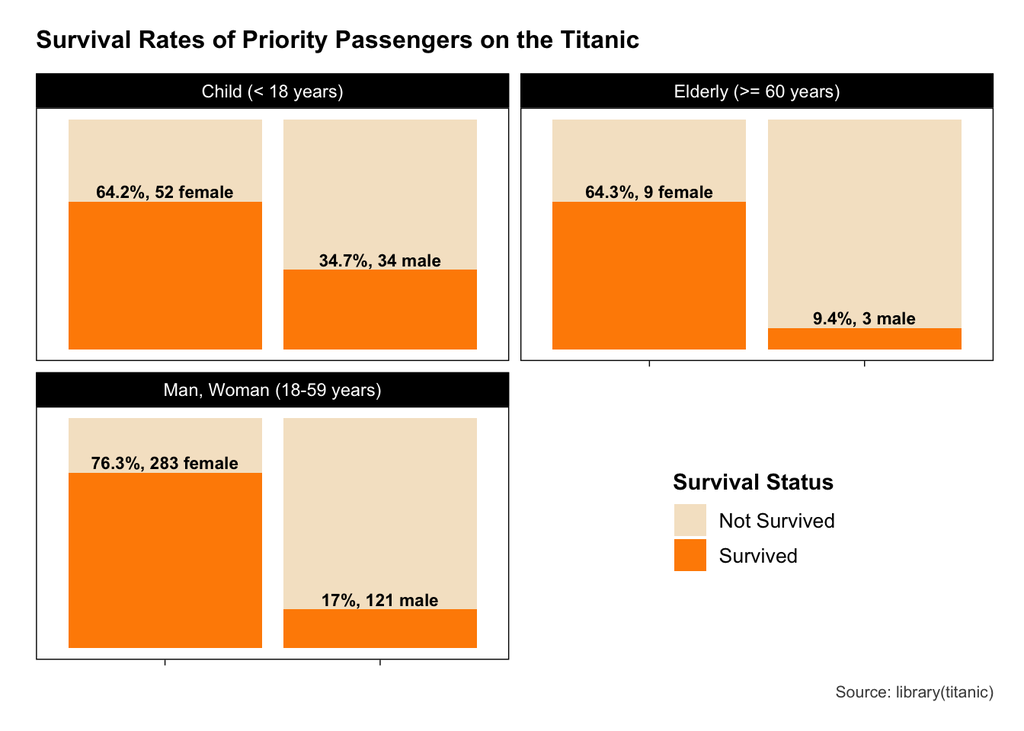

```r
label_chart <- c("Survival Rates of Priority Passengers on the Titanic","Source: library(titanic)")
finalize_titanic_data |>
  mutate(Priority_passengers = case_when( Age < 18 ~ "Child (< 18 years)",
      Age >= 60 ~ "Elderly (>= 60 years)", TRUE ~ "Man, Woman (18-59 years)"),
    Survived = ifelse(Survived == 1, "Survived", "Not Survived")) |>
  group_by(Priority_passengers, Sex) |> mutate(total_in_group = n()) |>
  group_by(Sex, Priority_passengers, Survived) |>
  summarise(n = n(),total_in_group = first(total_in_group),.groups = "drop") |>
  mutate(percent = round((n / total_in_group) * 100, 1),label_text = ifelse(Survived %in% c("Survived"),
    paste0(percent, "%, ", n, " ", Sex), NA)) |> ggplot(aes(Sex, percent, fill = Survived)) + geom_col() +
  geom_text(aes(label = label_text), vjust = -0.3, size = 3, fontface = "bold", na.rm = TRUE) +
  scale_fill_manual(values = c("Not Survived" = "#f5e4cb", "Survived" = "darkorange"),
    name = "Survival Status"
  ) + facet_wrap(~ Priority_passengers, nrow = 2, ncol = 2, scales = "fixed") +
  custom_theme +
  theme(axis.title.y = element_blank(), axis.title.x = element_blank(),
    axis.text.y = element_blank(), axis.text.x = element_blank(),
    axis.ticks.y = element_blank(), panel.grid.major.y = element_blank(),
    panel.grid.major.x = element_blank(), panel.grid.minor.y = element_blank(),
    legend.position = c(0.75, 0.25), legend.direction = "vertical",
    legend.title = element_text(face = "bold"), legend.text = element_text(size = 10)
  ) + labs(title = label_chart[1], caption = label_chart[2])
```

## 5.4 Tabulated of Survival Rates by Passenger Class (Pclass)

สร้าง ตารางดูสัดส่วนคนรอดชีวิต (Survived) แบ่งตามชั้นผู้โดยสาร (Pclass)

```r
summary_Pclass_survived <- finalize_titanic_data |>
  mutate(Pclass = case_when(Pclass == 1 ~ "Passenger_Class_1",
                            Pclass == 2 ~ "Passenger_Class_2",
                            TRUE ~ "Passenger_Class_3"  )) |>
  count(Survived,Pclass) |>
  pivot_wider(names_from = Survived, values_from = n, values_fill = 0) |>
  mutate(Total = `0` + `1`, `%Total` = (Total / nrow(finalize_titanic_data)) |> percent(accuracy = 1))
colnames(summary_Pclass_survived) <- c("Pclass", "Not_Survived",
                                         "Survived", "Total", "%Total")
sum_total_survived <- summary_Pclass_survived |>
  summarise(Not_Survived = sum(Not_Survived),Survived = sum(Survived),
            Total = sum(Total)) |>
  mutate(`%Total` = "")
summary_Pclass_survived <- summary_Pclass_survived |>
  bind_rows(sum_total_survived) |>
  mutate(Pclass = coalesce(Pclass, "Total")) |>
  mutate(across(everything(), as.character)) |>
  bind_rows(summary_Pclass_survived[10, ] |>
              mutate(
                Pclass = ifelse(is.na(Pclass),"%Total", Pclass),
                Not_Survived = (
                  sum(summary_Pclass_survived$Not_Survived) / nrow(finalize_titanic_data)) |>
                  percent(accuracy = 1),
                Survived = (
                  sum(summary_Pclass_survived$Survived) / nrow(finalize_titanic_data)) |>
                  percent(accuracy = 1),
                Total = ifelse(is.na(Total), "", Total),
                `%Total` = "100%"
              )) |> kable()
summary_Pclass_survived
```

| Pclass | Not_Survived | Survived | Total | %Total |
| --- | --- | --- | --- | --- |
| Passenger_Class_1 | 124 | 199 | 323 | 25% |
| Passenger_Class_2 | 158 | 119 | 277 | 21% |
| Passenger_Class_3 | 525 | 184 | 709 | 54% |
| Total | 807 | 502 | 1309 |  |
| %Total | 62% | 38% |  | 100% |

### 5.4.1 Horizontal Bar Chart of Survival Rates by Passenger Class (Pclass)

สร้าง Horizontal Bar Chart ดูสัดส่วนคนรอดชีวิต (Survived) แบ่งตามชั้นผู้โดยสาร (Pclass)

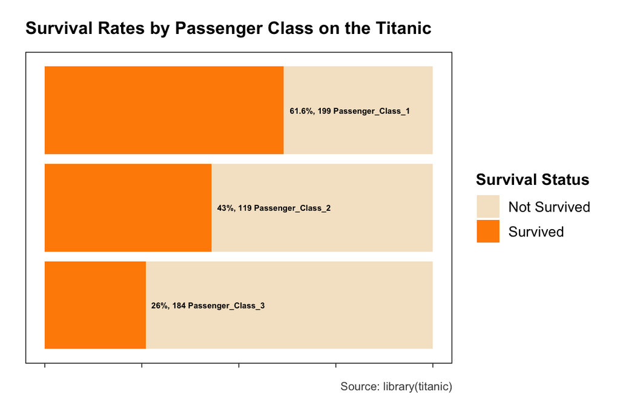

```r
finalize_titanic_data |>
  mutate(Survived = ifelse(Survived == 1, "Survived", "Not Survived"),
         Pclass = case_when(Pclass == 1 ~ "Passenger_Class_1",
                            Pclass == 2 ~ "Passenger_Class_2",
                            TRUE ~ "Passenger_Class_3"  ),
         Pclass = factor(Pclass, levels = c("Passenger_Class_3", "Passenger_Class_2",
                                            "Passenger_Class_1"))) |>
  group_by(Pclass) |> mutate(total_in_group = n()) |> group_by(Pclass, Survived) |>
  summarise(n = n(), total_in_group = first(total_in_group)) |>
  mutate(percent = round((n / total_in_group) * 100, 1),
         label_text = ifelse(Survived %in% c("Survived"),
               paste0(percent, "%, ", n, " ", Pclass), NA)) |>
  ggplot(aes(Pclass, percent, fill = Survived)) + geom_col() + coord_flip() +
  geom_text(aes(label = label_text), hjust = -0.05, size = 2, fontface = "bold", na.rm = TRUE) +
  scale_fill_manual(values = c("Not Survived" = "#f5e4cb", "Survived" = "darkorange"),
                    name = "Survival Status"
  ) + custom_theme +
  theme(axis.title.y = element_blank(), axis.title.x = element_blank(),
        axis.text.y = element_blank(), axis.text.x = element_blank(),
        axis.ticks.y = element_blank(), panel.grid.major.y = element_blank(),
        panel.grid.major.x = element_blank(), panel.grid.minor.y = element_blank(),
        legend.title = element_text(face = "bold"), legend.text = element_text(size = 10)
  ) + labs(title = "Survival Rates by Passenger Class on the Titanic",
           caption = "Source: library(titanic)")
```

## 5.5 Boxplot of Ticket Prices by Class and Survival on the Titanic

สร้าง Boxplot ดูการกระจายตัวของราคาตั๋ว (Fare) แบ่งตามชั้นผู้โดยสาร (Pclass)

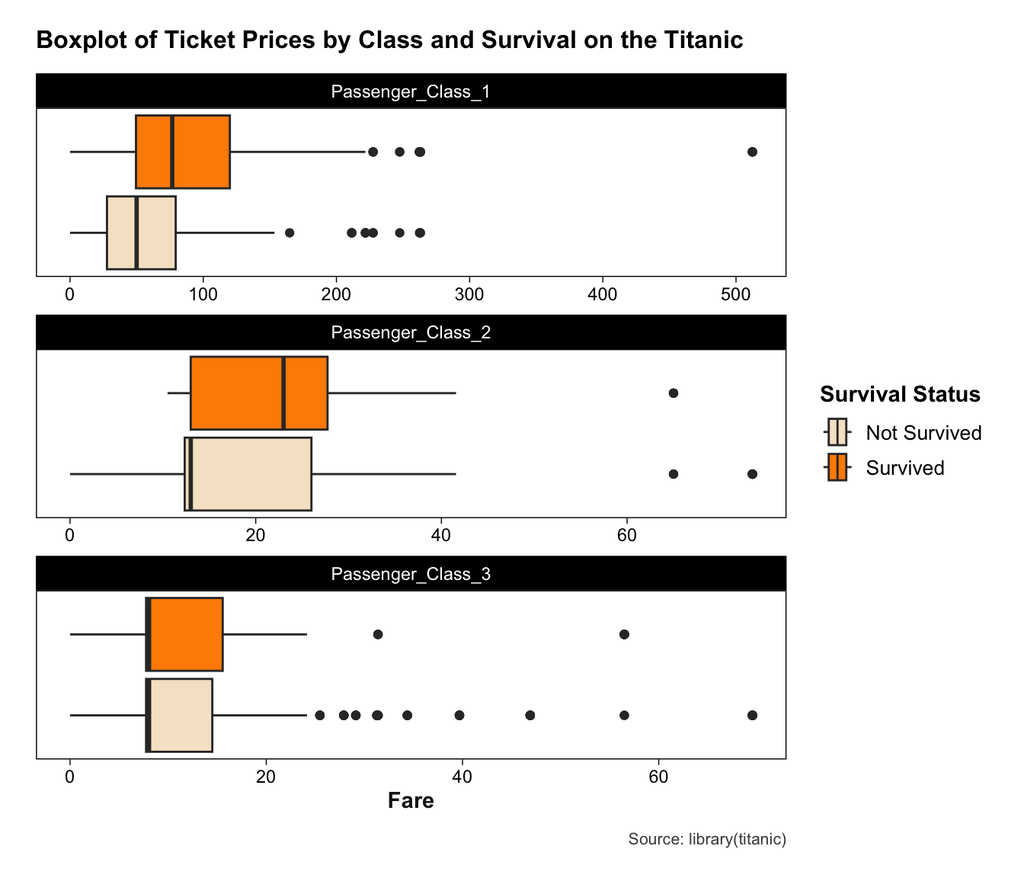

```r
finalize_titanic_data |>
  mutate(Pclass = case_when(Pclass == 1 ~ "Passenger_Class_1", Pclass == 2 ~ "Passenger_Class_2",
                            TRUE ~ "Passenger_Class_3"  ),
         Survived = ifelse(Survived == 1, "Survived", "Not Survived")) |>
  ggplot(aes(x = Fare, fill = Survived)) + geom_boxplot() +
  scale_fill_manual(values = c("Not Survived" = "#f5e4cb", "Survived" = "darkorange"),
                    name = "Survival Status") + custom_theme +
  theme(axis.title.y = element_blank(), axis.ticks.y = element_blank(),
        panel.grid.major.x = element_blank(), panel.grid.minor.x = element_blank(),
        panel.grid.major.y = element_blank(), panel.grid.minor.y = element_blank(),
        legend.title = element_text(face = "bold"), legend.text = element_text(size = 10),
        legend.position = "right", legend.direction = "vertical", axis.text.y = element_blank()
  ) + facet_wrap(~ Pclass, ncol = 1, nrow = 3, scales = "free_x") +
  labs(title = "Boxplot of Ticket Prices by Class and Survival on the Titanic",
    caption = "Source: library(titanic)", y = "Fare (Ticket Price : £)")
```

### 5.5.1 Basic Stats (Boxplot) of Ticket Prices by Class and Survival on the Titanic

สร้างตารางคำนวณสถิติเบื้องต้นที่ใช้อธิบาย Boxplot ในแต่ละชั้นผู้โดยสารและการรอดชีวิตบนเรือ

```r
pclass_vec <- finalize_titanic_data$Pclass |> unique() |> sort()
survived_vec <- finalize_titanic_data$Survived |> unique() |> sort(decreasing = TRUE)

boxplot_value <- list()

for (i in pclass_vec) {
  for (j in survived_vec) {
    set_fare <- finalize_titanic_data |>
      filter(Pclass == i & Survived == j) |>
      select(Fare) |>
      pull(Fare)
    boxplot_value[[length(boxplot_value) + 1]] <- round(
      c(
        summary(set_fare),
        "lower_whisker" = boxplot.stats(set_fare)$stats[1],
        "upper_whisker" = boxplot.stats(set_fare)$stats[5],
        "n_data" = boxplot.stats(set_fare)$n,
        "n_outlier" = boxplot.stats(set_fare)$out |> length(),
        "SD" = sd(set_fare),
        "IQR" = boxplot.stats(set_fare)$stats[3] - boxplot.stats(set_fare)$stats[1]
      ), 1
    )
    names(boxplot_value)[length(boxplot_value)] <- paste0("P-", i, " & ", "S-", j)
  }
}
table_dist_fare_passenger <- data.frame(boxplot_value) |> t()
colnames(table_dist_fare_passenger) <- c(
  "Min","Q1", "Median", "Mean",
  "Q3", "Max", "LoBound",
  "UpBound", "N", "N_Out",
  "SD", "IQR")
table_dist_fare_passenger <- as_data_frame(table_dist_fare_passenger)
table_dist_fare_passenger$Class_Surv <- c("P-1 & S-1", "P-1 & S-0", "P-2 & S-1",
                                          "P-2 & S-0", "P-3 & S-1", "P-3 & S-0")
table_dist_fare_passenger |>
  select(Class_Surv, N, Min, LoBound, Q1,
         Median, Mean, Q3, UpBound, Max,
         N_Out, IQR, SD) |> kable()
```

[output not shown]

## 5.6 Explore impact of FamilySize (from Parch & SibSp) on survival using histogram

สร้าง Family_Size จาก Parch, Sibsp สำรวจดูว่ามีโอกาสรอดมากน้อยแค่ไหนด้วย Histogram

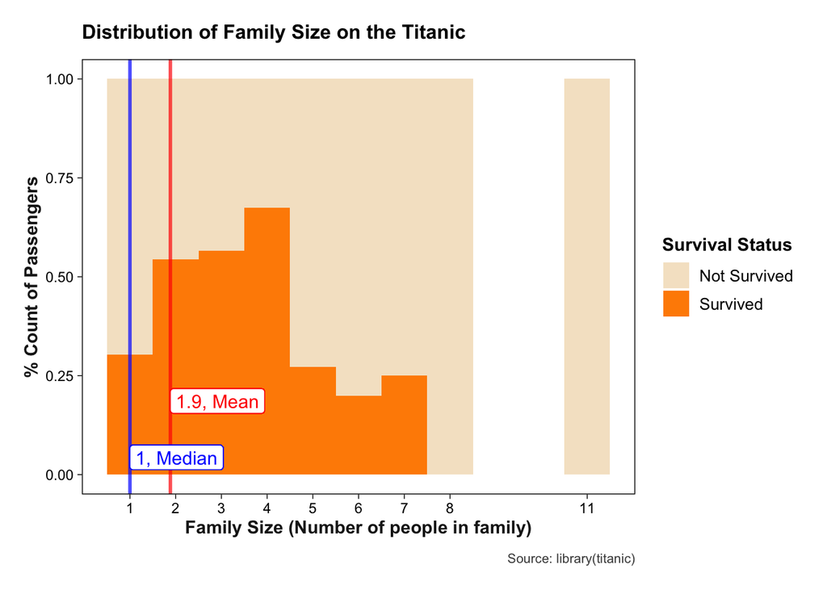

```r
titanic_data_with_family_info <- finalize_titanic_data |>
  mutate(
  Family_Size = Parch + SibSp + 1,
  # แปลง Survived และ Pclass เป็น Factor/Character เพื่อให้กราฟสวยงามและเหมาะสม
  Survived = factor(Survived, levels = c(0, 1), labels = c("Not Survived", "Survived"))
)

# --- เริ่มสร้าง Histogram/Density plot ของ Family_Size ---

# 1. Histogram ของ Family_Size พร้อม Overlay Mean และ Median
# คำนวณค่า Mean และ Median ของ Family_Size
mean_family_size <- mean(titanic_data_with_family_info$Family_Size)
median_family_size <- median(titanic_data_with_family_info$Family_Size)

ggplot(titanic_data_with_family_info, aes(x = Family_Size, fill = Survived)) +
  geom_histogram(binwidth = 1, position = "fill") + # เพิ่ม alpha กลับมาเพื่อให้มองเห็นสี fill
  geom_vline(aes(xintercept = mean_family_size), linetype = "solid", color = "red", size = 1, alpha = 0.7) + # กำหนด color ตรงๆ
  geom_vline(aes(xintercept = median_family_size), linetype = "solid", color = "blue", size = 1, alpha = 0.7) + # กำหนด color ตรงๆ
  # ----------------------------------------------------
# เพิ่ม geom_text เพื่อเป็น Label บนกราฟ
  geom_label(
    x = mean_family_size,
    y = min(ggplot_build(ggplot(titanic_data_with_family_info, aes(x = Family_Size)) +
                           geom_histogram(binwidth = 1))$data[[1]]$count), # ตำแหน่ง Label
    label = paste0(round(mean_family_size, 1), ", Mean"), # รูปแบบ "1.8, mean"
    color = "red", # สีของข้อความให้ตรงกับเส้น
    vjust = -2.5, # ปรับตำแหน่งแนวตั้งของข้อความ (ค่าบวกเลื่อนลง, ค่าลบเลื่อนขึ้น)
    hjust = 0, # ปรับตำแหน่งแนวนอนของข้อความ (ค่าบวกเลื่อนขวา, ค่าลบเลื่อนซ้าย)
    size = 4,
    angle = 0, # หมุนข้อความ 90 องศา เพื่อให้ไม่ทับกันและอ่านง่าย
    fill = "white"
  ) +
  geom_label(
    x = median_family_size,
    y = min(ggplot_build(ggplot(titanic_data_with_family_info, aes(x = Family_Size)) +
                           geom_histogram(binwidth = 1))$data[[1]]$count), # ตำแหน่ง Label
    label = paste0(round(median_family_size, 1), ", Median"), # รูปแบบ "1, median"
    color = "blue", # สีของข้อความให้ตรงกับเส้น
    vjust = -0.2, # ปรับตำแหน่งแนวตั้ง
    hjust = 0, # ปรับตำแหน่งแนวนอน
    size = 4,
    angle = 0, # หมุนข้อความ 90 องศา
    fill = "white"
  ) +
  guides(color = "none") + # <-- ซ่อน Legend ของ Mean/Median
  scale_fill_manual(values = c("Not Survived" = "#f5e4cb", "Survived" = "darkorange"),
                    name = "Survival Status") +
  labs(
    title = "Distribution of Family Size on the Titanic",
    x = "Family Size (Number of people in family)",
    y = "% Count of Passengers",
    caption = "Source: library(titanic)"
  ) +
  scale_x_continuous(breaks = unique(titanic_data_with_family_info$Family_Size)) +
  custom_theme +
  theme(
      panel.grid.major.x = element_blank(), panel.grid.minor.x = element_blank(),
      panel.grid.major.y = element_blank(), panel.grid.minor.y = element_blank(),

  )
```

### 5.6.1 Explore impact of Travel Style (from Parch & SibSp) on survival using Table.

สร้างตารางสำรวจรูปการเดินทางมีผลต่อการรอดชีวิตของผู้โดยสารบนเรือหรือไม่

```r
titanic_data_with_travel_style <- finalize_titanic_data |>
  mutate(
    Family_Size = Parch + SibSp + 1,
    Travel_Style = case_when(
      Family_Size == 1 ~ "Alone",
      Parch > 0 & SibSp == 0 ~ "With Parents/Children Only",
      Parch == 0 & SibSp > 0 ~ "With Siblings/Spouse Only",
      Parch > 0 & SibSp > 0 ~ "With Mixed Family",
      TRUE ~ "Unknown" # กรณีที่ไม่ตรงกับเงื่อนไขใดๆ หรือ NA
    ),
    # แปลง Survived และ Pclass เป็น Factor/Character เพื่อให้กราฟสวยงามและเหมาะสม
    Survived = factor(Survived, levels = c(0, 1), labels = c("Not_Survived", "Survived"))
  ) |>
  count(Survived,Travel_Style) |>
  pivot_wider(names_from = Survived, values_from = n, values_fill = 0) |>
  mutate(Total = Not_Survived + Survived, `%Total` = (Total / nrow(finalize_titanic_data)) |> percent(accuracy = 1))
sum_total_survived <- titanic_data_with_travel_style |>
  summarise(Not_Survived = sum(Not_Survived),Survived = sum(Survived),
            Total = sum(Total)) |>
  mutate(`%Total` = "")
titanic_data_with_travel_style <- titanic_data_with_travel_style |>
  bind_rows(sum_total_survived) |>
  mutate(Travel_Style = coalesce(Travel_Style, "Total")) |>
  mutate(across(everything(), as.character)) |>
  bind_rows(titanic_data_with_travel_style[10, ] |>
  mutate(
    Travel_Style = ifelse(is.na(Travel_Style),"%Total", Travel_Style),
    Not_Survived = (
      sum(titanic_data_with_travel_style$Not_Survived) / nrow(finalize_titanic_data)) |>
      percent(accuracy = 1),
    Survived = (
      sum(titanic_data_with_travel_style$Survived) / nrow(finalize_titanic_data)) |>
      percent(accuracy = 1),
    Total = ifelse(is.na(Total), "", Total),
    `%Total` = "100%"
  )) |> kable()
titanic_data_with_travel_style
```

| Travel_Style | Not_Survived | Survived | Total | %Total |
| --- | --- | --- | --- | --- |
| Alone | 550 | 240 | 790 | 60% |
| With Mixed Family | 113 | 93 | 206 | 16% |
| With Parents/Children Only | 31 | 70 | 101 | 8% |
| With Siblings/Spouse Only | 113 | 99 | 212 | 16% |
| Total | 807 | 502 | 1309 |  |
| %Total | 62% | 38% |  | 100% |

### 5.6.2 Impact of Family Travel Companions on Titanic Passenger Survival

สร้าง Bar Chart แสดงรูปการเดินทางของผู้โดยสาร

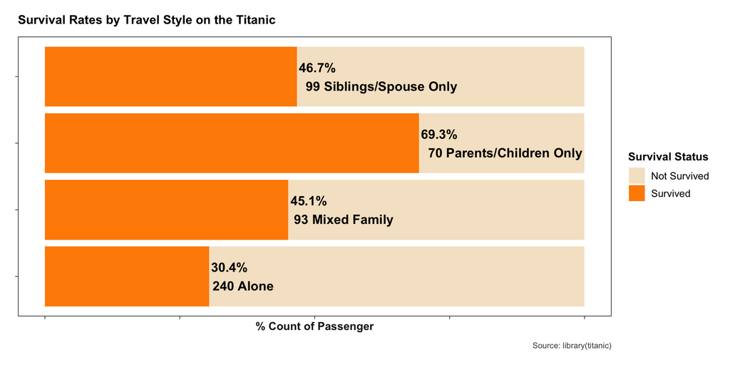

```r
data_travel_style <- finalize_titanic_data |>
  mutate(
    Family_Size = Parch + SibSp + 1,
    Travel_Style = case_when(
      Family_Size == 1 ~ "Alone",
      Parch > 0 & SibSp == 0 ~ "Parents/Children Only",
      Parch == 0 & SibSp > 0 ~ "Siblings/Spouse Only",
      Parch > 0 & SibSp > 0 ~ "Mixed Family",
      TRUE ~ "Unknown" # กรณีที่ไม่ตรงกับเงื่อนไขใดๆ หรือ NA
    ),
    # แปลง Survived และ Pclass เป็น Factor/Character เพื่อให้กราฟสวยงามและเหมาะสม
    Survived = factor(Survived, levels = c(0, 1), labels = c("Not Survived", "Survived"))
  ) |>
  group_by(Travel_Style) |> mutate(total_in_group = n()) |>
  group_by(Travel_Style, Survived) |>
  summarise(
    n = n(),total_in_group = first(total_in_group),
    .groups = "drop"
  ) |>
  mutate(
    percent_n = round((n / total_in_group) * 100, 1),
    label_text = ifelse(Survived %in% c("Survived"),
    paste0(percent_n, "%\n", n, " ", Travel_Style),
    NA
    )
  )

bar_chart_travel_style <- data_travel_style |>
  ggplot(aes(x = Travel_Style, y = percent_n, fill = Survived)) +
  geom_col() +
  scale_fill_manual(values = c("Not Survived" = "#f5e4cb", "Survived" = "darkorange"),
                    name = "Survival Status") + coord_flip() +
  geom_text(aes(label = label_text), hjust = -0.06, size = 4.5, fontface = "bold", na.rm = TRUE) +
  custom_theme +
  theme(
    axis.text.x = element_blank(), axis.text.y = element_blank(),
    axis.title.y = element_blank(), legend.title = element_text(face = "bold"),
    legend.position = "right", legend.direction = "vertical",) +
  labs(title = "Survival Rates by Travel Style on the Titanic",
       caption = "Source: library(titanic)", y = "% Count of Passenger")

bar_chart_travel_style
```

## 5.7 Visualizing Relationships Among Variables Within the Titanic Dataset

แสดงค่าความสัมพันธ์ (Correlation) ระหว่างตัวแปรในชุดข้อมูล Titanic สีแดง = ความสัมพันธ์เชิงลบ, สีเขียว = ความสัมพันธ์เชิงบวก

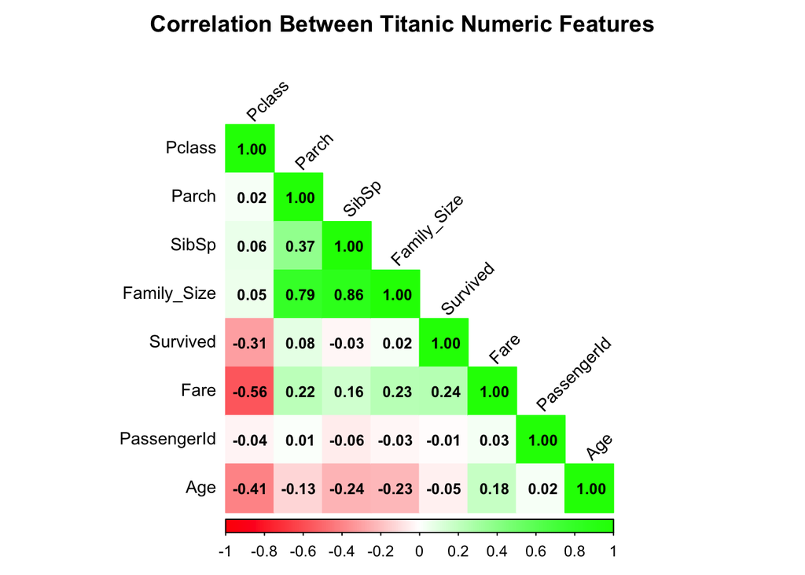

```r
correlation_matrix_titanic <- finalize_titanic_data |>
  mutate(
    Family_Size = Parch + SibSp + 1
  ) |>
  select(where(is.numeric)) |>
  cor(use = "everything", method = "pearson") |> # use = "pairwise.complete.obs" ใช้เมื่อเจอ NA
  round(2)

# ตั้งค่า layout ล่วงหน้าให้กราฟขนาดเหมาะสม
# คุณสามารถปรับขนาดกราฟได้จากข้างล่างนี้
# (เช่น ถ้าใช้ใน RMarkdown หรือ RStudio Viewer)
par(mar = c(1, 1, 4, 1)) # ปรับขอบ margin รอบกราฟ

# สร้างกราฟ corrplot พร้อมส่วนเพิ่มเติม
corrplot(
  correlation_matrix_titanic,
  method = "color",
  type = "lower",
  order = "hclust",
  tl.col = "black",
  addCoef.col = "black",
  tl.srt = 45,
  tl.cex = 0.9,
  number.cex = 0.8,
  col = colorRampPalette(c("red", "white", "green"))(200),
  title = "Correlation Between Titanic Numeric Features",
  mar = c(0,0,2,0) # ปรับพื้นที่ด้านบนเพื่อให้ title แสดงพอดี
)
```

```r
correlation_matrix_titanic |> kable()
```

|  | PassengerId | Survived | Pclass | Age | SibSp | Parch | Fare | Family_Size |
| --- | --- | --- | --- | --- | --- | --- | --- | --- |
| PassengerId | 1.00 | -0.01 | -0.04 | 0.02 | -0.06 | 0.01 | 0.03 | -0.03 |
| Survived | -0.01 | 1.00 | -0.31 | -0.05 | -0.03 | 0.08 | 0.24 | 0.02 |
| Pclass | -0.04 | -0.31 | 1.00 | -0.41 | 0.06 | 0.02 | -0.56 | 0.05 |
| Age | 0.02 | -0.05 | -0.41 | 1.00 | -0.24 | -0.13 | 0.18 | -0.23 |
| SibSp | -0.06 | -0.03 | 0.06 | -0.24 | 1.00 | 0.37 | 0.16 | 0.86 |
| Parch | 0.01 | 0.08 | 0.02 | -0.13 | 0.37 | 1.00 | 0.22 | 0.79 |
| Fare | 0.03 | 0.24 | -0.56 | 0.18 | 0.16 | 0.22 | 1.00 | 0.23 |
| Family_Size | -0.03 | 0.02 | 0.05 | -0.23 | 0.86 | 0.79 | 0.23 | 1.00 |